# Predicting Future Music Trends Using a Centuries' Worth of Data

By Kian Abdi

[figure not shown]

## Introduction

Music is an art that can connect people from every single culture and edge of our vast world. With thousands of new songs being created/released daily, the ebb and flow of music appear to be endless. Throughout history, music has been communicated through many mediums and forms, but as more music comes into existence, more data about various music trends will be at our disposal. The ideal collection of this data occurs in the world of streaming, with services such as Spotify anchoring data for hundreds of thousands of songs.

To fully analyze these trends, we will be looking at a couple of datasets that contain song data for over 600 thousand songs, with the different sets being sorted by genre, artist, and year from 1921-2021. Furthermore, we will also be trying to see if it is possible to create a predictive model of a "combination" variable using the fundamentals of regression. This way we can use this project to predict future trends that may continue in music.

The datasets being used were accessed using the Spotify API, you can learn more about Spotify here: https://www.spotify.com/us/

Here is an article described some of the current changes that music is undergoing, see if you can find any similarities during our analysis! https://business-review.eu/lifestyle/music/trends-that-will-reshape-the-music-industry-216932

Furthermore, here is some more documentation for some of the libraries we will be using, feel free to refer to these resouces if you want to go further in-depth: https://pandas.pydata.org/docs/ https://seaborn.pydata.org/ https://matplotlib.org/stable/contents.html https://scikit-learn.org/stable/

## Data Analysis

To begin our analysis, we will using following libraries: pandas, seaborn, and matplotlib. We will also import numpy for future use.

```python
# Importing necessary libraries for Data Analysis
import pandas as pd
import numpy as np
import matplotlib.pyplot as plt
import seaborn as sns
```

```python
# Read in dataset from current project directory as a dataframe
data = pd.read_csv("data_o.csv")
data.dropna()
data.head()
```

|  | valence | year | acousticness | artists | danceability | duration_ms | energy | explicit | id | instrumentalness | key | liveness | loudness | mode | name | popularity | release_date | speechiness | tempo |
| --- | --- | --- | --- | --- | --- | --- | --- | --- | --- | --- | --- | --- | --- | --- | --- | --- | --- | --- | --- |
| 0 | 0.0594 | 1921 | 0.982 | ['Sergei Rachmaninoff', 'James Levine', 'Berli... | 0.279 | 831667 | 0.211 | 0 | 4BJqT0PrAfrxzMOxytFOIz | 0.878000 | 10 | 0.665 | -20.096 | 1 | Piano Concerto No. 3 in D Minor, Op. 30: III. ... | 4 | 1921 | 0.0366 | 80.954 |
| 1 | 0.9630 | 1921 | 0.732 | ['Dennis Day'] | 0.819 | 180533 | 0.341 | 0 | 7xPhfUan2yNtyFG0cUWkt8 | 0.000000 | 7 | 0.160 | -12.441 | 1 | Clancy Lowered the Boom | 5 | 1921 | 0.4150 | 60.936 |
| 2 | 0.0394 | 1921 | 0.961 | ['KHP Kridhamardawa Karaton Ngayogyakarta Hadi... | 0.328 | 500062 | 0.166 | 0 | 1o6I8BglA6ylDMrIELygv1 | 0.913000 | 3 | 0.101 | -14.850 | 1 | Gati Bali | 5 | 1921 | 0.0339 | 110.339 |
| 3 | 0.1650 | 1921 | 0.967 | ['Frank Parker'] | 0.275 | 210000 | 0.309 | 0 | 3ftBPsC5vPBKxYSee08FDH | 0.000028 | 5 | 0.381 | -9.316 | 1 | Danny Boy | 3 | 1921 | 0.0354 | 100.109 |
| 4 | 0.2530 | 1921 | 0.957 | ['Phil Regan'] | 0.418 | 166693 | 0.193 | 0 | 4d6HGyGT8e121BsdKmw9v6 | 0.000002 | 3 | 0.229 | -10.096 | 1 | When Irish Eyes Are Smiling | 2 | 1921 | 0.0380 | 101.665 |

```python
# Read in dataset from current project directory as a dataframe
data_by_year = pd.read_csv("data_by_year_o.csv")
data_by_year.dropna()
data_by_year.head()
```

|  | mode | year | acousticness | danceability | duration_ms | energy | instrumentalness | liveness | loudness | speechiness | tempo | valence | popularity | key |
| --- | --- | --- | --- | --- | --- | --- | --- | --- | --- | --- | --- | --- | --- | --- |
| 0 | 1 | 1921 | 0.886896 | 0.418597 | 260537.166667 | 0.231815 | 0.344878 | 0.205710 | -17.048667 | 0.073662 | 101.531493 | 0.379327 | 0.653333 | 2 |
| 1 | 1 | 1922 | 0.938592 | 0.482042 | 165469.746479 | 0.237815 | 0.434195 | 0.240720 | -19.275282 | 0.116655 | 100.884521 | 0.535549 | 0.140845 | 10 |
| 2 | 1 | 1923 | 0.957247 | 0.577341 | 177942.362162 | 0.262406 | 0.371733 | 0.227462 | -14.129211 | 0.093949 | 114.010730 | 0.625492 | 5.389189 | 0 |
| 3 | 1 | 1924 | 0.940200 | 0.549894 | 191046.707627 | 0.344347 | 0.581701 | 0.235219 | -14.231343 | 0.092089 | 120.689572 | 0.663725 | 0.661017 | 10 |
| 4 | 1 | 1925 | 0.962607 | 0.573863 | 184986.924460 | 0.278594 | 0.418297 | 0.237668 | -14.146414 | 0.111918 | 115.521921 | 0.621929 | 2.604317 | 5 |

```python
# Read in dataset from current project directory as a dataframe
data_by_artist = pd.read_csv("data_by_artist_o.csv")
data_by_artist.dropna()
data_by_artist.head()
```

|  | genres | artists | acousticness | danceability | duration_ms | energy | instrumentalness | liveness | loudness | speechiness | tempo | valence | popularity | key | mode | count |
| --- | --- | --- | --- | --- | --- | --- | --- | --- | --- | --- | --- | --- | --- | --- | --- | --- |
| 0 | ['show tunes'] | "Cats" 1981 Original London Cast | 0.590111 | 0.467222 | 250318.555556 | 0.394003 | 0.011400 | 0.290833 | -14.448000 | 0.210389 | 117.518111 | 0.389500 | 38.333333 | 5 | 1 | 9 |
| 1 | [] | "Cats" 1983 Broadway Cast | 0.862538 | 0.441731 | 287280.000000 | 0.406808 | 0.081158 | 0.315215 | -10.690000 | 0.176212 | 103.044154 | 0.268865 | 30.576923 | 5 | 1 | 26 |
| 2 | [] | "Fiddler On The Roof” Motion Picture Chorus | 0.856571 | 0.348286 | 328920.000000 | 0.286571 | 0.024593 | 0.325786 | -15.230714 | 0.118514 | 77.375857 | 0.354857 | 34.857143 | 0 | 1 | 7 |
| 3 | [] | "Fiddler On The Roof” Motion Picture Orchestra | 0.884926 | 0.425074 | 262890.962963 | 0.245770 | 0.073587 | 0.275481 | -15.639370 | 0.123200 | 88.667630 | 0.372030 | 34.851852 | 0 | 1 | 27 |
| 4 | [] | "Joseph And The Amazing Technicolor Dreamcoat"... | 0.510714 | 0.467143 | 270436.142857 | 0.488286 | 0.009400 | 0.195000 | -10.236714 | 0.098543 | 122.835857 | 0.482286 | 43.000000 | 5 | 1 | 7 |

```python
data_by_genres = pd.read_csv("data_by_genres_o.csv")
data_by_genres.dropna()
data_by_genres.head()
```

|  | mode | genres | acousticness | danceability | duration_ms | energy | instrumentalness | liveness | loudness | speechiness | tempo | valence | popularity | key |
| --- | --- | --- | --- | --- | --- | --- | --- | --- | --- | --- | --- | --- | --- | --- |
| 0 | 1 | 21st century classical | 0.979333 | 0.162883 | 1.602977e+05 | 0.071317 | 0.606834 | 0.361600 | -31.514333 | 0.040567 | 75.336500 | 0.103783 | 27.833333 | 6 |
| 1 | 1 | 432hz | 0.494780 | 0.299333 | 1.048887e+06 | 0.450678 | 0.477762 | 0.131000 | -16.854000 | 0.076817 | 120.285667 | 0.221750 | 52.500000 | 5 |
| 2 | 1 | 8-bit | 0.762000 | 0.712000 | 1.151770e+05 | 0.818000 | 0.876000 | 0.126000 | -9.180000 | 0.047000 | 133.444000 | 0.975000 | 48.000000 | 7 |
| 3 | 1 | [] | 0.651417 | 0.529093 | 2.328809e+05 | 0.419146 | 0.205309 | 0.218696 | -12.288965 | 0.107872 | 112.857352 | 0.513604 | 20.859882 | 7 |
| 4 | 1 | a cappella | 0.676557 | 0.538961 | 1.906285e+05 | 0.316434 | 0.003003 | 0.172254 | -12.479387 | 0.082851 | 112.110362 | 0.448249 | 45.820071 | 7 |

At a first look, some of the column names appear to be confusing, especially with their scaling. Luckily with the Spotify API: https://developer.spotify.com/documentation/web-api/reference/#category-tracks we are able to loosely understand how some of the columns in our dataframes are conceived. Let's take a look at a few of the descriptions from the API to see if we can find anything interesting.

- Acousticness - A confidence measure from 0.0 to 1.0 of whether the track is acoustic. 1.0 represents high confidence the track is acoustic.
- Danceability - describes how suitable a track is for dancing based on a combination of musical elements including tempo, rhythm stability, beat strength, and overall regularity. A value of 0.0 is least danceable and 1.0 is most danceable.
- Energy - Energy is a measure from 0.0 to 1.0 and represents a perceptual measure of intensity and activity. Typically, energetic tracks feel fast, loud, and noisy. For example, death metal has high energy, while a Bach prelude scores low on the scale. Perceptual features contributing to this attribute include dynamic range, perceived loudness, timbre, onset rate, and general entropy.
- Loudness - The overall loudness of a track in decibels (dB). Loudness values are averaged across the entire track and are useful for comparing relative loudness of tracks. Loudness is the quality of a sound that is the primary psychological correlate of physical strength (amplitude). Values typical range between -60 and 0 db.
- Popularity - The popularity of the track. The value will be between 0 and 100, with 100 being the most popular. The popularity is calculated by algorithm and is based, in the most part, on the total number of plays the track has had and how recent those plays are.
- Speechiness - Speechiness detects the presence of spoken words in a track. The more exclusively speech-like the recording (e.g. talk show, audio book, poetry), the closer to 1.0 the attribute value. Values above 0.66 describe tracks that are probably made entirely of spoken words. Values between 0.33 and 0.66 describe tracks that may contain both music and speech, either in sections or layered, including such cases as rap music. Values below 0.33 most likely represent music and other non-speech-like tracks.
- Valence - A measure from 0.0 to 1.0 describing the musical positiveness conveyed by a track. Tracks with high valence sound more positive (e.g. happy, cheerful, euphoric), while tracks with low valence sound more negative (e.g. sad, depressed, angry).

The majority of the above variables are derived from a single aspect of a track, but one that stands out in Danceability. Danceability is described as a "combination" of several musical elements. Although we can't exactly pinpoint the exact combination of factors, we will figure out a way to approach this later on in the tutorial. Danceability should be a very interesting variable to hone it, since its nature as a "combination" variables leads me to believe that the variable may be a very good indicator of future trends in music overall.

Next, let us take a look at how the metrics from API have evolved with some scatterplots. To do this, we will utilize our dataframe that is sorted by year. Note we are also importing some new methods from sklearn, as we will be using linear regression with our plots.

Here is some documenation that documents how to make use of scipy's linear regression: https://scikit-learn.org/stable/modules/generated/sklearn.linear_model.LinearRegression.html https://medium.com/analytics-vidhya/linear-regression-in-python-from-scratch-with-scipy-statsmodels-sklearn-da8e373cc89b

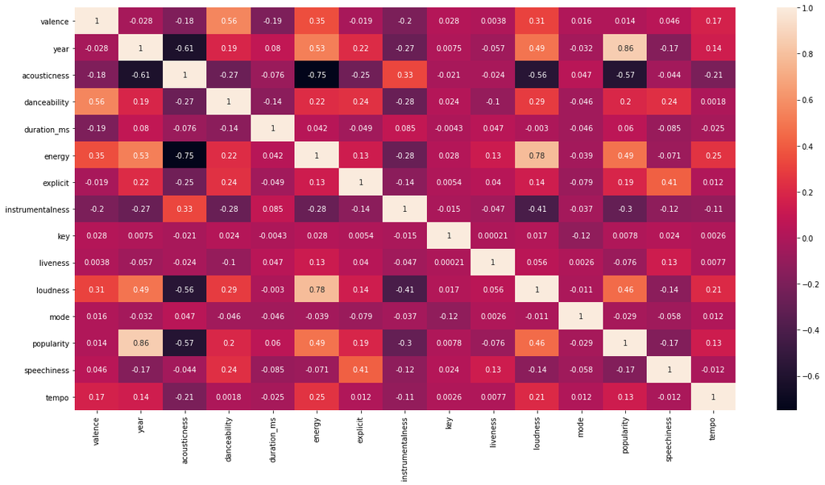

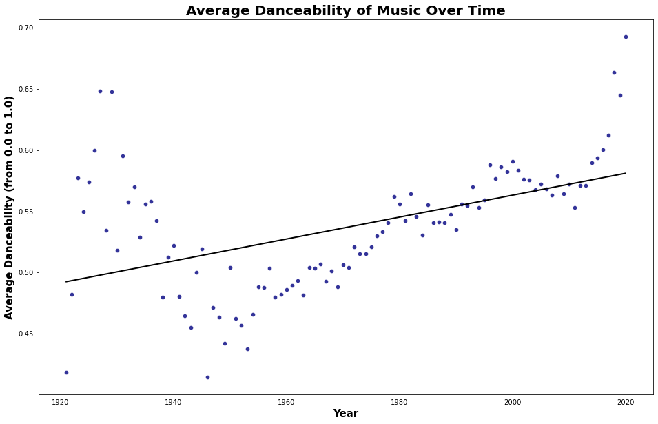

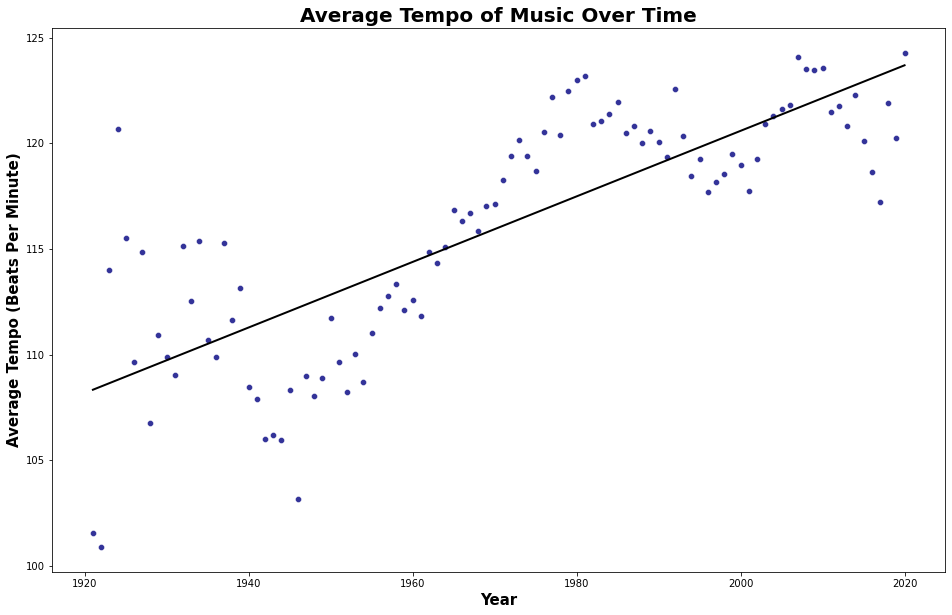

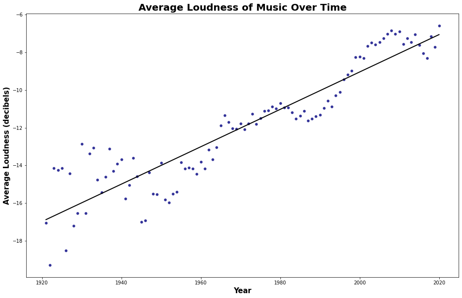

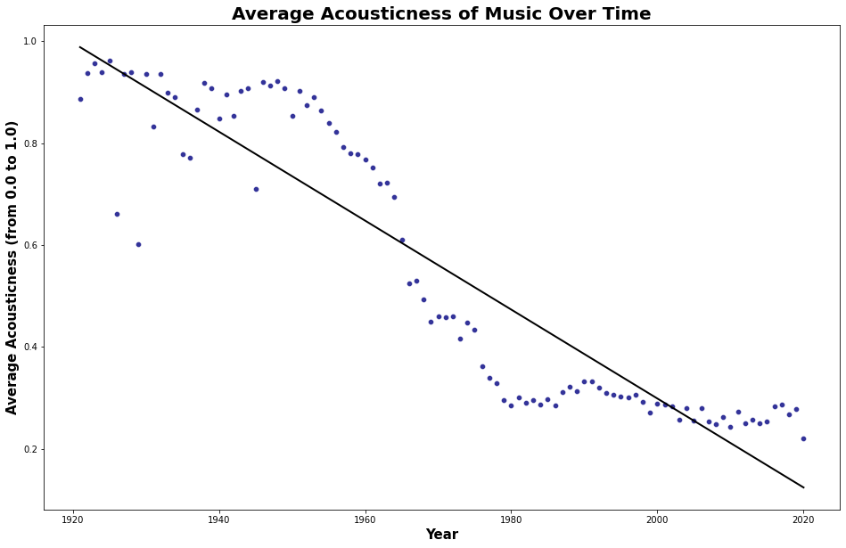

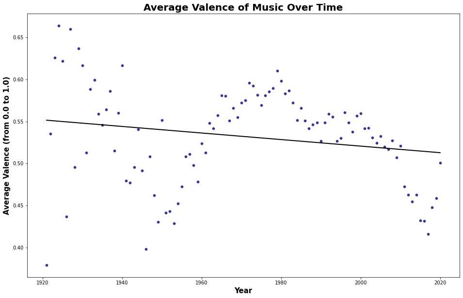

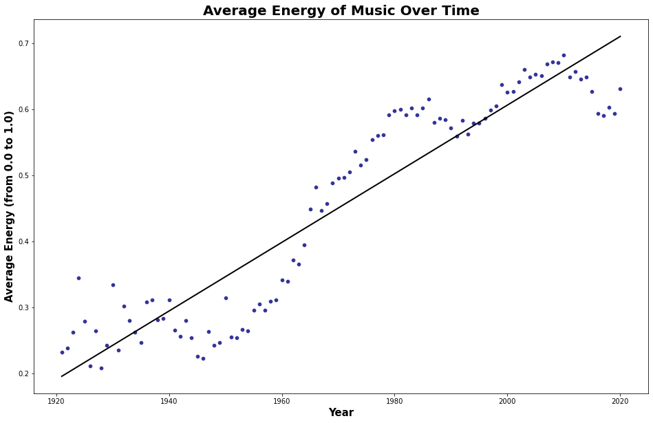

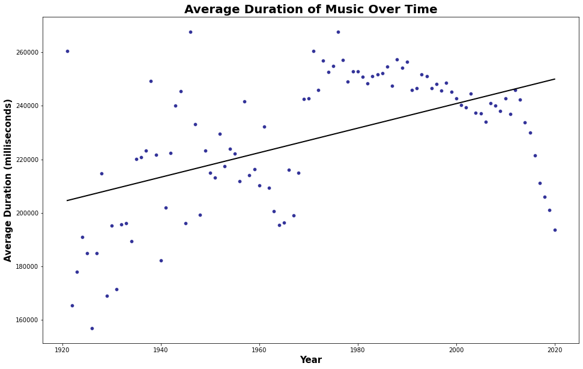

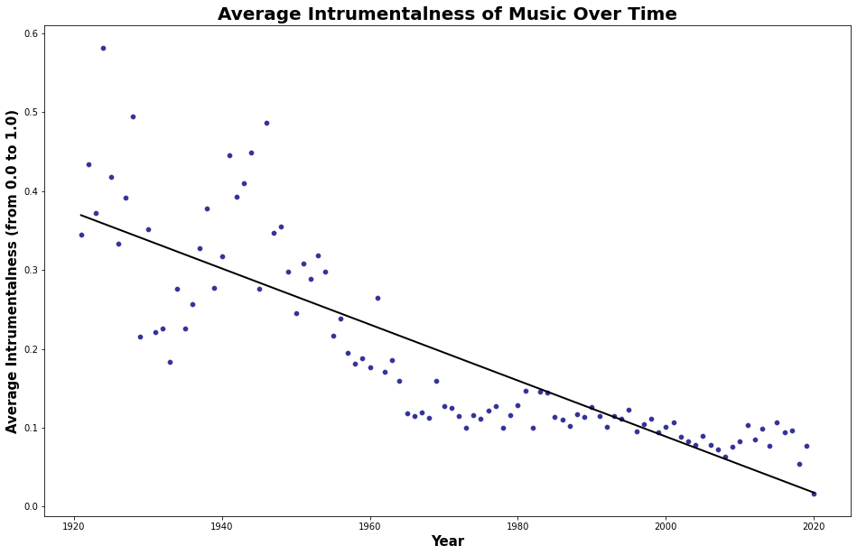

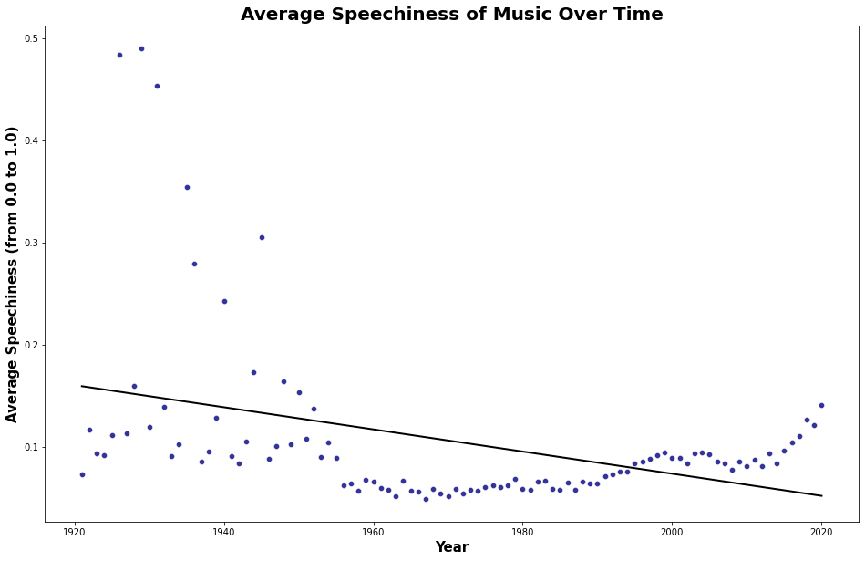

```python
# Importing linear regression for line of best fit on plot
from sklearn.linear_model import LinearRegression

# Set up correlation matrix to get initial idea of possible relations between columns
# A higher number in the heatmap indicates a higher correlation between variables!
plt.figure(figsize = (20, 10))
corrMatrix = data.corr()
sns.heatmap(corrMatrix, annot=True)
plt.show()

# creating list of lsits with year data for model training
X = [[i] for i in data_by_year['year']]

# fit linear regression for the data
linreg = LinearRegression()
linreg.fit(X, data_by_year['danceability'])

# make predictions with use of the training set
prediction = linreg.predict(X)

# Label, Setup, and Plot a scatterplot of how dancebility has evolved over time
plt.figure(figsize = (16, 10))
plt.xlabel('Year', fontsize=15, fontweight='bold')
plt.ylabel('Average Danceability (from 0.0 to 1.0)', fontsize=15, fontweight='bold')
plt.title('Average Danceability of Music Over Time', fontsize=20, fontweight='bold')
sns.scatterplot(x=data_by_year['year'], y=data_by_year['danceability'], alpha=0.8, color=["navy"])
# plot line of best fit using model prediction from the linear regression
plt.plot(data_by_year['year'], prediction, color = "black", linewidth = 2)
plt.show()

# fit linear regression for the data
linreg = LinearRegression()
linreg.fit(X, data_by_year['tempo'])

# make predictions with use of the training set
prediction = linreg.predict(X)

# Label, Setup, and Plot a scatterplot of how tempo has evolved over time
plt.figure(figsize = (16, 10))
plt.xlabel('Year', fontsize=15, fontweight='bold')
plt.ylabel('Average Tempo (Beats Per Minute)', fontsize=15, fontweight='bold')
plt.title('Average Tempo of Music Over Time', fontsize=20, fontweight='bold')
sns.scatterplot(x=data_by_year['year'], y=data_by_year['tempo'], alpha=0.8, color=["navy"])
plt.plot(data_by_year['year'], prediction, color = "black", linewidth = 2)
plt.show()

linreg = LinearRegression()
linreg.fit(X, data_by_year['loudness'])

# make predictions with use of the training set
prediction = linreg.predict(X)

# Label, Setup, and Plot a scatterplot of how loudness has evolved over time
plt.figure(figsize = (16, 10))
plt.xlabel('Year', fontsize=15, fontweight='bold')
plt.ylabel('Average Loudness (decibels)', fontsize=15, fontweight='bold')
plt.title('Average Loudness of Music Over Time', fontsize=20, fontweight='bold')
sns.scatterplot(x=data_by_year['year'], y=data_by_year['loudness'], alpha=0.8, color=["navy"])
plt.plot(data_by_year['year'], prediction, color = "black", linewidth = 2)
plt.show()


linreg = LinearRegression()
linreg.fit(X, data_by_year['acousticness'])

# make predictions with use of the training set
prediction = linreg.predict(X)

# Label, Setup, and Plot a scatterplot of how acousticness has evolved over time
plt.figure(figsize = (16, 10))
plt.xlabel('Year', fontsize=15, fontweight='bold')
plt.ylabel('Average Acousticness (from 0.0 to 1.0)', fontsize=15, fontweight='bold')
plt.title('Average Acousticness of Music Over Time', fontsize=20, fontweight='bold')
sns.scatterplot(x=data_by_year['year'], y=data_by_year['acousticness'], alpha=0.8, color=["navy"])
plt.plot(data_by_year['year'], prediction, color = "black", linewidth = 2)
plt.show()


linreg = LinearRegression()
linreg.fit(X, data_by_year['valence'])

# make predictions with use of the training set
prediction = linreg.predict(X)

# Label, Setup, and Plot a scatterplot of how valence has evolved over time
plt.figure(figsize = (16, 10))
plt.xlabel('Year', fontsize=15, fontweight='bold')
plt.ylabel('Average Valence (from 0.0 to 1.0)', fontsize=15, fontweight='bold')
plt.title('Average Valence of Music Over Time', fontsize=20, fontweight='bold')
sns.scatterplot(x=data_by_year['year'], y=data_by_year['valence'], alpha=0.8, color=["navy"])
plt.plot(data_by_year['year'], prediction, color = "black", linewidth = 2)
plt.show()


linreg = LinearRegression()
linreg.fit(X, data_by_year['energy'])

# make predictions with use of the training set
prediction = linreg.predict(X)

# Label, Setup, and Plot a scatterplot of how energy has evolved over time
plt.figure(figsize = (16, 10))
plt.xlabel('Year', fontsize=15, fontweight='bold')
plt.ylabel('Average Energy (from 0.0 to 1.0)', fontsize=15, fontweight='bold')
plt.title('Average Energy of Music Over Time', fontsize=20, fontweight='bold')
sns.scatterplot(x=data_by_year['year'], y=data_by_year['energy'], alpha=0.8, color=["navy"])
plt.plot(data_by_year['year'], prediction, color = "black", linewidth = 2)
plt.show()


linreg = LinearRegression()
linreg.fit(X, data_by_year['duration_ms'])

# make predictions with use of the training set
prediction = linreg.predict(X)

# Label, Setup, and Plot a scatterplot of how duration_ms has evolved over time
plt.figure(figsize = (16, 10))
plt.xlabel('Year', fontsize=15, fontweight='bold')
plt.ylabel('Average Duration (milliseconds)', fontsize=15, fontweight='bold')
plt.title('Average Duration of Music Over Time', fontsize=20, fontweight='bold')
sns.scatterplot(x=data_by_year['year'], y=data_by_year['duration_ms'], alpha=0.8, color=["navy"])
plt.plot(data_by_year['year'], prediction, color = "black", linewidth = 2)
plt.show()


linreg = LinearRegression()
linreg.fit(X, data_by_year['instrumentalness'])

# make predictions with use of the training set
prediction = linreg.predict(X)

# Label, Setup, and Plot a scatterplot of how instrumentalness has evolved over time
plt.figure(figsize = (16, 10))
plt.xlabel('Year', fontsize=15, fontweight='bold')
plt.ylabel('Average Intrumentalness (from 0.0 to 1.0)', fontsize=15, fontweight='bold')
plt.title('Average Intrumentalness of Music Over Time', fontsize=20, fontweight='bold')
sns.scatterplot(x=data_by_year['year'], y=data_by_year['instrumentalness'], alpha=0.8, color=["navy"])
plt.plot(data_by_year['year'], prediction, color = "black", linewidth = 2)
plt.show()


linreg = LinearRegression()
linreg.fit(X, data_by_year['speechiness'])

# make predictions with use of the training set
prediction = linreg.predict(X)

# Label, Setup, and Plot a scatterplot of how speechiness has evolved over time
plt.figure(figsize = (16, 10))
plt.xlabel('Year', fontsize=15, fontweight='bold')
plt.ylabel('Average Speechiness (from 0.0 to 1.0)', fontsize=15, fontweight='bold')
plt.title('Average Speechiness of Music Over Time', fontsize=20, fontweight='bold')
sns.scatterplot(x=data_by_year['year'], y=data_by_year['speechiness'], alpha=0.8, color=["navy"])
plt.plot(data_by_year['year'], prediction, color = "black", linewidth = 2)
plt.show()
```

As we can see, there are very obvious correlations and fluctuations between most of the variables we graphed across a one-hundred-year span. Now before we move on, let us take a look at some of these plots to see if we can make any surface-level assumptions of any trend or fluctuation. In the Danceability, Valence, Energy, and Tempo graphs, for example, I notice that there is a slight dip in the increasing trend during the mid-'40s. What happened in the 1940's you may ask? World War 2 is what happened, and although we can no way say this conclusively, it would make sense that the overall liveliness of music decreased during such a difficult time. Furthermore, since Valence, Energy, and Tempo experienced a drop during wartime as Danceability did, we should keep in mind that these Valence, Energy, and Tempo are potentially factored into Spotify's Danceability calculation. Another example that we can speculate on is the Speechiness graph, as the slight increase in speeches over the past couple of decades may be attributed to the prevalence of rap music in the realm of pop culture.

In Addition, from our heatmap we can see that the most heavily correlating variable to Danceability is Valence, so let us keep this in mind when trying to break down Danceability further in a little bit.

As for our next step, let us take some time to find some further insights from our data, and see if we can figure out the factors that go into a combination variable like Danceability.

## Exploratory Data Analysis

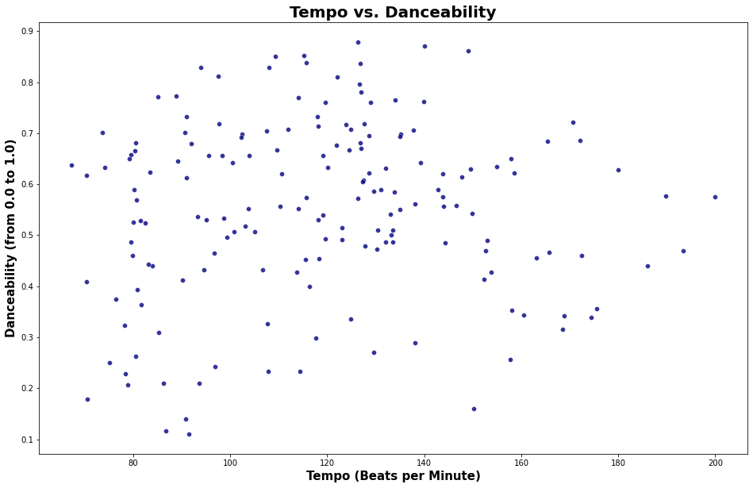

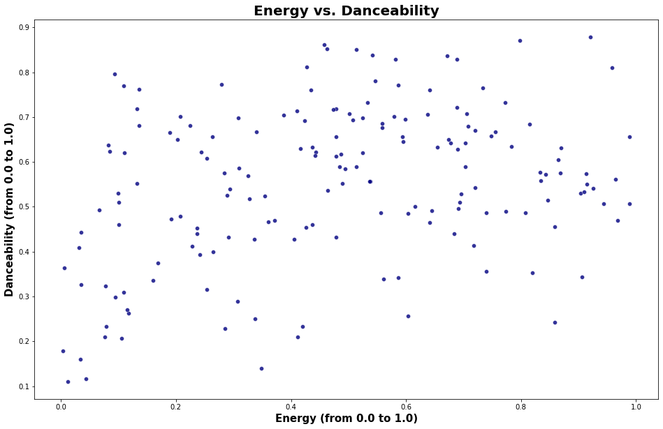

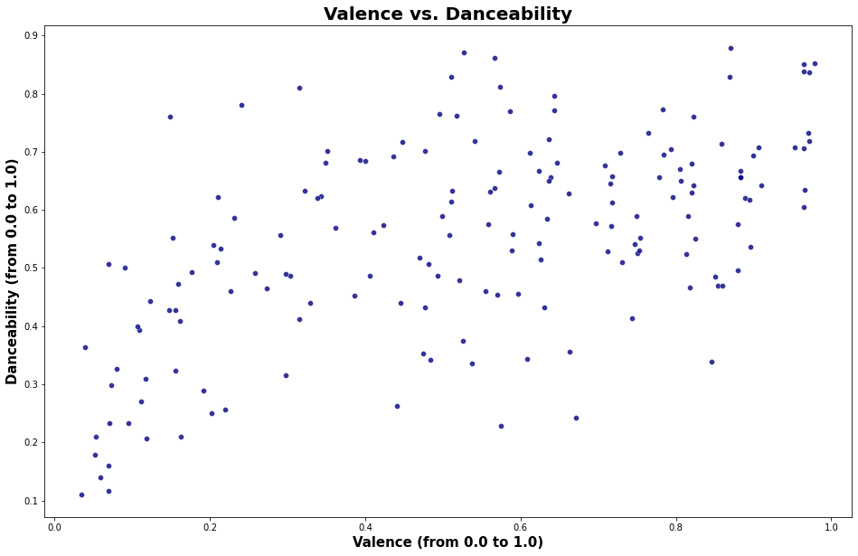

```python
## Finding trends for danceabiltiy

# Take portion of songs since there are so many for plotting
data_portion = data.sample(frac=0.001)

# Label, Setup, and Plot a scatterplot of how tempo compares to danceability
plt.figure(figsize = (16, 10))
plt.xlabel('Tempo (Beats per Minute)', fontsize=15, fontweight='bold')
plt.ylabel('Danceability (from 0.0 to 1.0)', fontsize=15, fontweight='bold')
plt.title('Tempo vs. Danceability', fontsize=20, fontweight='bold')
sns.scatterplot(x=data_portion['tempo'], y=data_portion['danceability'], alpha=0.8, color=["navy"])
plt.show()

# Label, Setup, and Plot a scatterplot of how energy compares to danceability
plt.figure(figsize = (16, 10))
plt.xlabel('Energy (from 0.0 to 1.0)', fontsize=15, fontweight='bold')
plt.ylabel('Danceability (from 0.0 to 1.0)', fontsize=15, fontweight='bold')
plt.title('Energy vs. Danceability', fontsize=20, fontweight='bold')
sns.scatterplot(x=data_portion['energy'], y=data_portion['danceability'], alpha=0.8, color=["navy"])
plt.show()

# Label, Setup, and Plot a scatterplot of how valence compares to danceability
plt.figure(figsize = (16, 10))
plt.xlabel('Valence (from 0.0 to 1.0)', fontsize=15, fontweight='bold')
plt.ylabel('Danceability (from 0.0 to 1.0)', fontsize=15, fontweight='bold')
plt.title('Valence vs. Danceability', fontsize=20, fontweight='bold')
sns.scatterplot(x=data_portion['valence'], y=data_portion['danceability'], alpha=0.8, color=["navy"])
plt.show()
```

Let us see if we can dig deeper into danceability using our genre-specific dataframe.

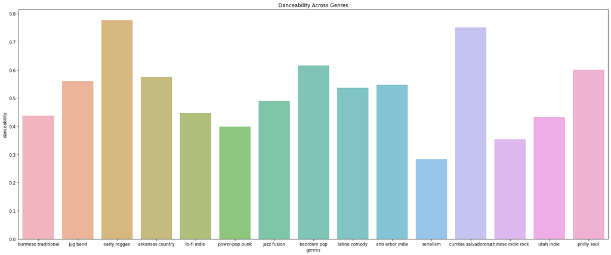

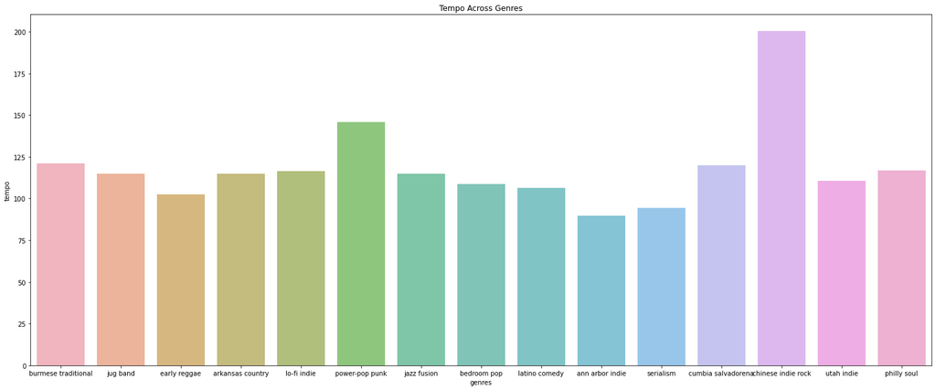

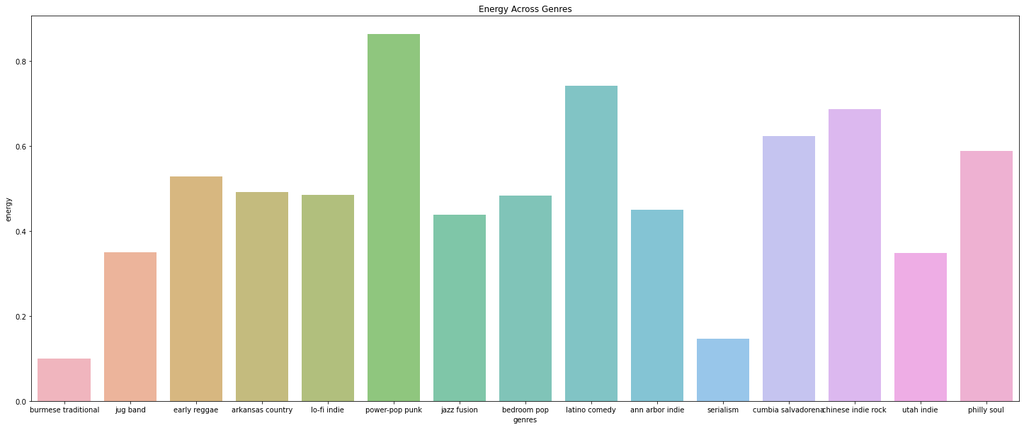

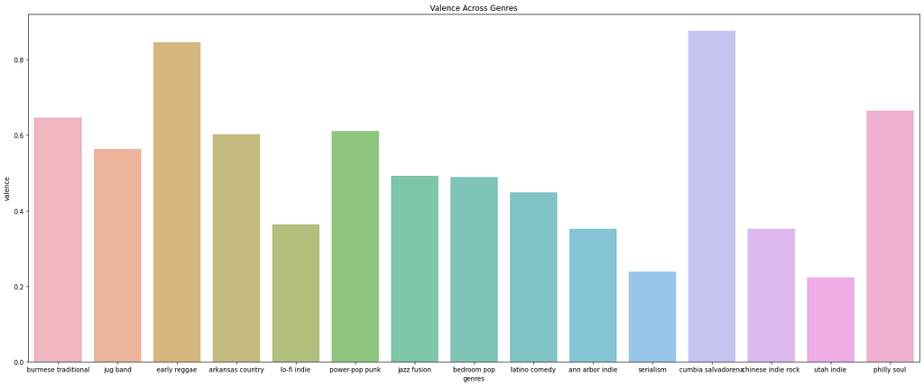

```python
# Portion out small sample of genres
data_genre_portion = data_by_genres.sample(frac=0.005)

# Plot the average danceability rating of our random sample of genres
plt.figure(figsize = (25, 10))
plt.title('Danceability Across Genres')
sns.barplot(x=data_genre_portion['genres'], y=data_genre_portion['danceability'], alpha=0.7)
plt.show()

# Plot the average tempo rating of our random sample of genres
plt.figure(figsize = (25, 10))
plt.title('Tempo Across Genres')
sns.barplot(x=data_genre_portion['genres'], y=data_genre_portion['tempo'], alpha=0.7)
plt.show()

# Plot the average energy rating of our random sample of genres
plt.figure(figsize = (25, 10))
plt.title('Energy Across Genres')
sns.barplot(x=data_genre_portion['genres'], y=data_genre_portion['energy'], alpha=0.7)
plt.show()

# Plot the average valence rating of our random sample of genres
plt.figure(figsize = (25, 10))
plt.title('Valence Across Genres')
sns.barplot(x=data_genre_portion['genres'], y=data_genre_portion['valence'], alpha=0.7)
plt.show()
```

Looking at the bar plots, it is a bit clearer to see visually as to why our previous attempts at a scatterplot for Danceability were not effective. Even though Valence, Energy, and Tempo follow the year-to-year trend of Danceability, there is still no direct correlation. Even if there was a direct correlation, the weights of other unknown factor elements would likely incur an unpredictable nature for danceability when it comes to viewing graphs.

Before we get to modeling, let us see if we can derive any further insights in regards to danceability using the other columns at our disposal, such as Popularity.

[figure not shown]

```python
plt.figure(figsize = (16, 10))
plt.xlabel('Popularity (from 0.0 to 1.0)', fontsize=15, fontweight='bold')
plt.ylabel('Danceability (from 0.0 to 1.0)', fontsize=15, fontweight='bold')
plt.title('Danceability vs. Popularity', fontsize=20, fontweight='bold')
sns.scatterplot(x=data_portion['danceability'], y=data_portion['popularity'], alpha=0.8, color=["navy"])
plt.show()
```

There still is no clear-cut correlation, but what happens if we consider splitting our data into time periods? At the beginning of this tutorial, we took note of the dip in Danceability during WW2, so it is possible that wrangling our data into time periods can give us the insight that we require. Let's continue by analyzing Popularity to see if we can translate any findings back to Danceability.

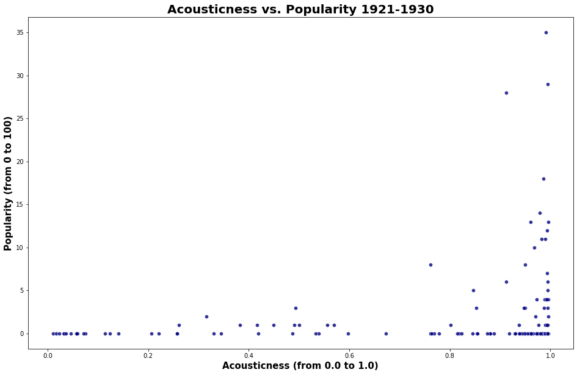

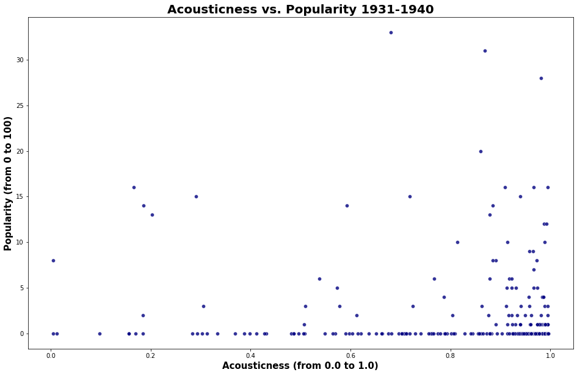

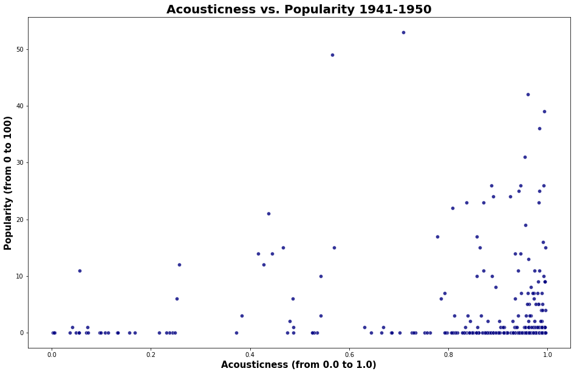

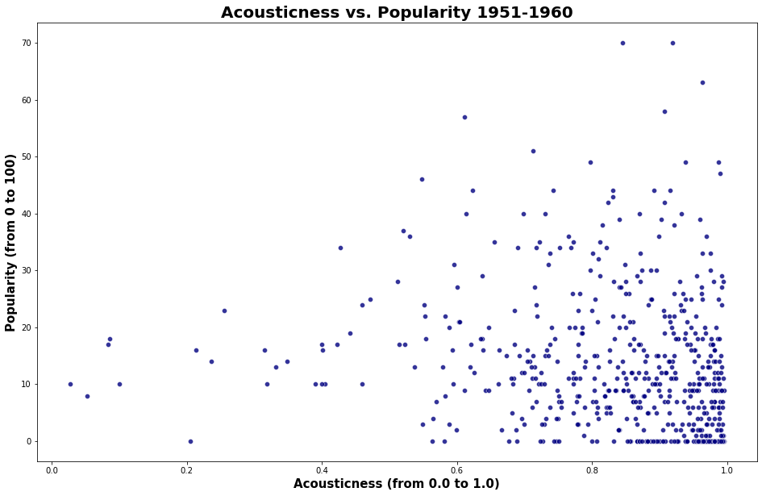

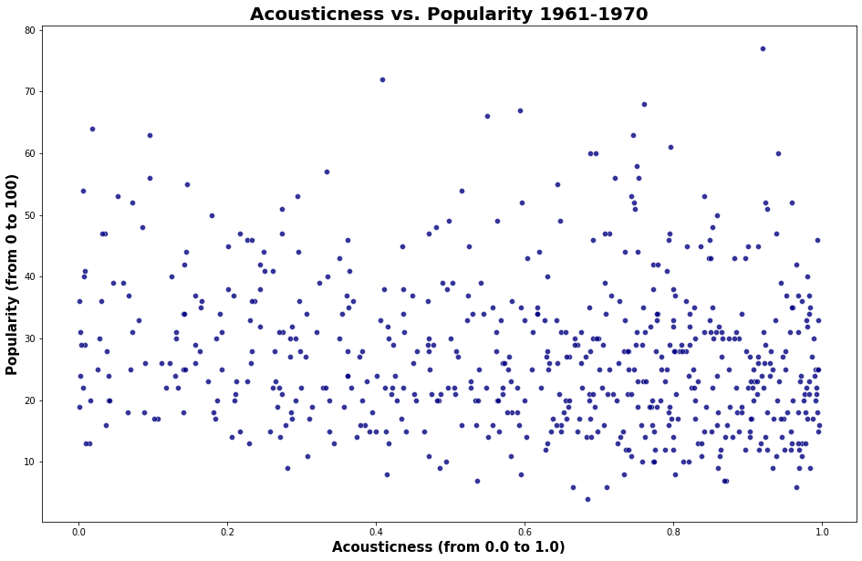

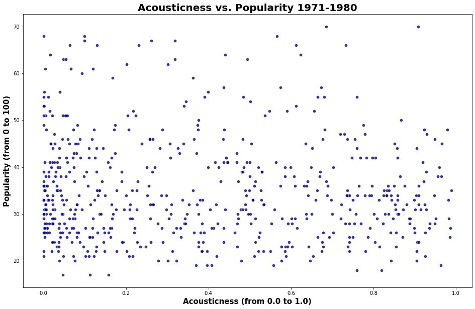

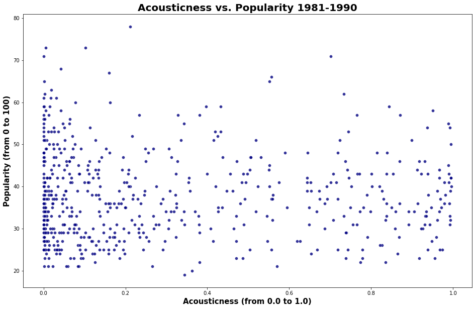

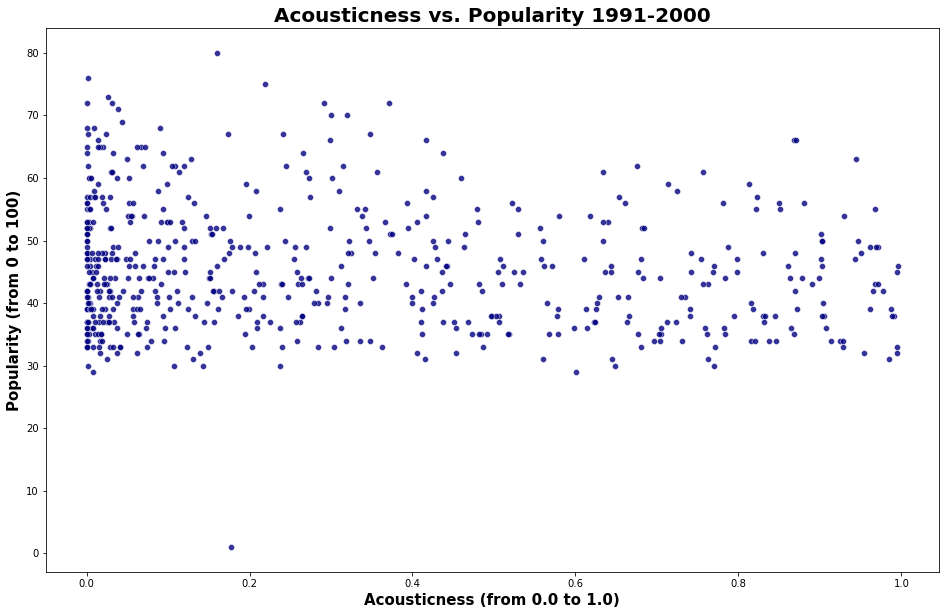

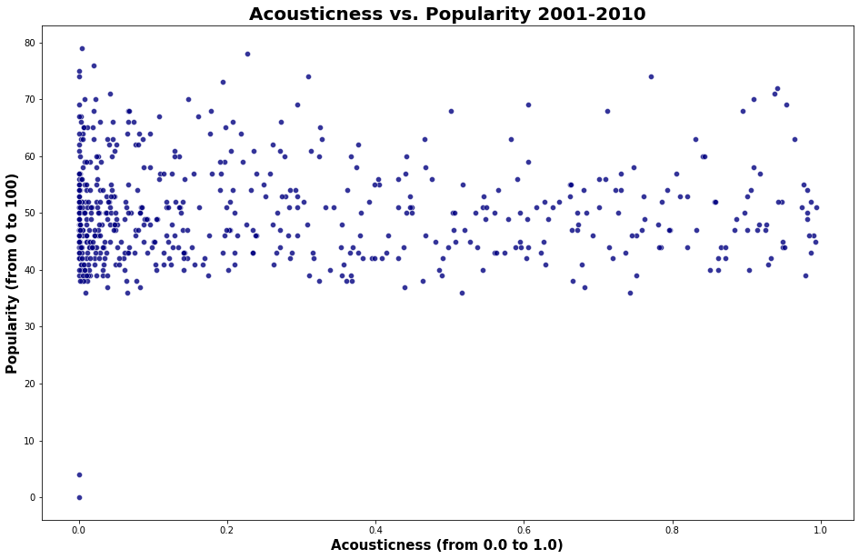

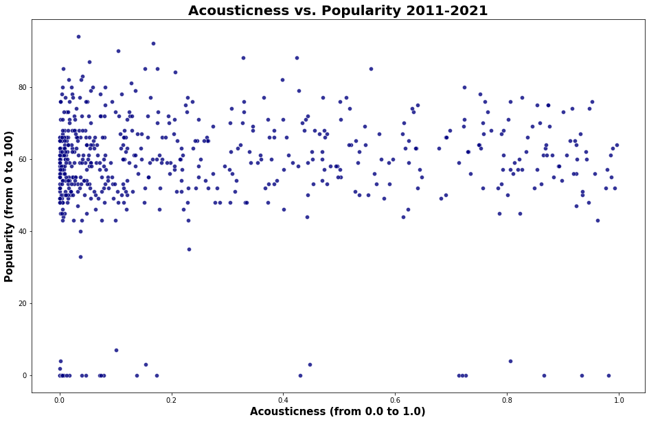

```python
# Period Popularity breakdown

#list of different time period for labeling purposes
time_periods = ['1921-1930', '1931-1940', '1941-1950', '1951-1960', '1961-1970', '1971-1980', '1981-1990', '1991-2000', '2001-2010', '2011-2021']
#create new column that bins the row based off year, using previously declared labeling
data['period'] = pd.cut(data.year, bins = 10, labels = time_periods)

# Dataframes for each time period, fractioned off for graph clearness
twenties = data[data.period == '1921-1930']
twenties_portion = twenties.sample(frac=0.03)

thirties = data[data.period == '1931-1940']
thirties_portion = thirties.sample(frac=0.03)

fourties = data[data.period == '1941-1950']
fourties_portion = fourties.sample(frac=0.03)

fifties = data[data.period == '1951-1960']
fifties_portion = fifties.sample(frac=0.03)

sixties = data[data.period == '1961-1970']
sixties_portion = sixties.sample(frac=0.03)

seventies = data[data.period == '1971-1980']
seventies_portion = seventies.sample(frac=0.03)

eighties = data[data.period == '1981-1990']
eighties_portion = eighties.sample(frac=0.03)

ninties = data[data.period == '1991-2000']
ninties_portion = ninties.sample(frac=0.03)

y2ks = data[data.period == '2001-2010']
y2ks_portion = y2ks.sample(frac=0.03)

twotens = data[data.period == '2011-2021']
twotens_portion = twotens.sample(frac=0.03)

# Plotting each period, starting off with acousticness vs popularity
plt.figure(figsize = (16, 10))
plt.xlabel('Acousticness (from 0.0 to 1.0)', fontsize=15, fontweight='bold')
plt.ylabel('Popularity (from 0 to 100)', fontsize=15, fontweight='bold')
plt.title('Acousticness vs. Popularity 1921-1930', fontsize=20, fontweight='bold')
sns.scatterplot(x=twenties_portion['acousticness'], y=twenties_portion['popularity'], alpha=0.8, color=["navy"])
plt.show()

plt.figure(figsize = (16, 10))
plt.xlabel('Acousticness (from 0.0 to 1.0)', fontsize=15, fontweight='bold')
plt.ylabel('Popularity (from 0 to 100)', fontsize=15, fontweight='bold')
plt.title('Acousticness vs. Popularity 1931-1940', fontsize=20, fontweight='bold')
sns.scatterplot(x=thirties_portion['acousticness'], y=thirties_portion['popularity'], alpha=0.8, color=["navy"])
plt.show()

plt.figure(figsize = (16, 10))
plt.xlabel('Acousticness (from 0.0 to 1.0)', fontsize=15, fontweight='bold')
plt.ylabel('Popularity (from 0 to 100)', fontsize=15, fontweight='bold')
plt.title('Acousticness vs. Popularity 1941-1950', fontsize=20, fontweight='bold')
sns.scatterplot(x=fourties_portion['acousticness'], y=fourties_portion['popularity'], alpha=0.8, color=["navy"])
plt.show()

plt.figure(figsize = (16, 10))
plt.xlabel('Acousticness (from 0.0 to 1.0)', fontsize=15, fontweight='bold')
plt.ylabel('Popularity (from 0 to 100)', fontsize=15, fontweight='bold')
plt.title('Acousticness vs. Popularity 1951-1960', fontsize=20, fontweight='bold')
sns.scatterplot(x=fifties_portion['acousticness'], y=fifties_portion['popularity'], alpha=0.8, color=["navy"])
plt.show()

plt.figure(figsize = (16, 10))
plt.xlabel('Acousticness (from 0.0 to 1.0)', fontsize=15, fontweight='bold')
plt.ylabel('Popularity (from 0 to 100)', fontsize=15, fontweight='bold')
plt.title('Acousticness vs. Popularity 1961-1970', fontsize=20, fontweight='bold')
sns.scatterplot(x=sixties_portion['acousticness'], y=sixties_portion['popularity'], alpha=0.8, color=["navy"])
plt.show()

plt.figure(figsize = (16, 10))
plt.xlabel('Acousticness (from 0.0 to 1.0)', fontsize=15, fontweight='bold')
plt.ylabel('Popularity (from 0 to 100)', fontsize=15, fontweight='bold')
plt.title('Acousticness vs. Popularity 1971-1980', fontsize=20, fontweight='bold')
sns.scatterplot(x=seventies_portion['acousticness'], y=seventies_portion['popularity'], alpha=0.8, color=["navy"])
plt.show()

plt.figure(figsize = (16, 10))
plt.xlabel('Acousticness (from 0.0 to 1.0)', fontsize=15, fontweight='bold')
plt.ylabel('Popularity (from 0 to 100)', fontsize=15, fontweight='bold')
plt.title('Acousticness vs. Popularity 1981-1990', fontsize=20, fontweight='bold')
sns.scatterplot(x=eighties_portion['acousticness'], y=eighties_portion['popularity'], alpha=0.8, color=["navy"])
plt.show()

plt.figure(figsize = (16, 10))
plt.xlabel('Acousticness (from 0.0 to 1.0)', fontsize=15, fontweight='bold')
plt.ylabel('Popularity (from 0 to 100)', fontsize=15, fontweight='bold')
plt.title('Acousticness vs. Popularity 1991-2000', fontsize=20, fontweight='bold')
sns.scatterplot(x=ninties_portion['acousticness'], y=ninties_portion['popularity'], alpha=0.8, color=["navy"])
plt.show()

plt.figure(figsize = (16, 10))
plt.xlabel('Acousticness (from 0.0 to 1.0)', fontsize=15, fontweight='bold')
plt.ylabel('Popularity (from 0 to 100)', fontsize=15, fontweight='bold')
plt.title('Acousticness vs. Popularity 2001-2010', fontsize=20, fontweight='bold')
sns.scatterplot(x=y2ks_portion['acousticness'], y=y2ks_portion['popularity'], alpha=0.8, color=["navy"])
plt.show()

plt.figure(figsize = (16, 10))
plt.xlabel('Acousticness (from 0.0 to 1.0)', fontsize=15, fontweight='bold')
plt.ylabel('Popularity (from 0 to 100)', fontsize=15, fontweight='bold')
plt.title('Acousticness vs. Popularity 2011-2021', fontsize=20, fontweight='bold')
sns.scatterplot(x=twotens_portion['acousticness'], y=twotens_portion['popularity'], alpha=0.8, color=["navy"])
plt.show()
```

We are finally seeing some trends! As you may have seen, over the past 10 decades popular music has been gradually becoming less acoustic, which can likely be attribute to the modern rise of electronically made music.